# SHELF_similarity_heatmap_distance

```r
#load spring and fall data
dat_SHELF_grid.reduced_3plustows <- readRDS("/Users/zoekitchel/Documents/grad school/Rutgers/Repositories/trawl_spatial_turnover/data/gridded/USA-SHELF/dat_SHELF_grid.reduced_3plustows.RData")
```

[output not shown]

Lists of Years

```r
#spring
dat_SHELF_grid.reduced_3plustows[,year:= as.numeric(year)] #make numeric
setorder(dat_SHELF_grid.reduced_3plustows, year)

shelf_years <- unique(dat_SHELF_grid.reduced_3plustows[,year])

#fall
#dat_SHELF_grid.fall.reduced_3plustows[,year:= as.numeric(year)] #make numeric
#setorder(dat_SHELF_grid.fall.reduced_3plustows, year)

#shelf_years_fall <- unique(dat_SHELF_grid.fall.reduced_3plustows[,year])
```

Haul ID keys

```r
shelf_haulids <- unique(dat_SHELF_grid.reduced_3plustows[,haulid])
shelf_haulids_key <- data.table(haulid = shelf_haulids, key_ID = seq(1,length(shelf_haulids), by = 1))

#shelf_fall_haulids <- unique(dat_SHELF_grid.fall.reduced_3plustows[,haulid])
#shelf_fall_haulids_key <- data.table(haulid = shelf_fall_haulids, key_ID = seq(1,length(shelf_fall_haulids), by = 1))
```

Convert haulids to numeric key_IDs

```r
#spring
dat_SHELF_grid.reduced_3plustows <- dat_SHELF_grid.reduced_3plustows[shelf_haulids_key, on = "haulid"]

#fall
#dat_SHELF_grid.fall.reduced_3plustows <- dat_SHELF_grid.fall.reduced_3plustows[shelf_fall_haulids_key, on = "haulid"]
```

Dissimilarities across multiple years SPRING

```r
shelf_distances_dissimilarities_allyears <- data.table("haulid1" = integer(), "haulid2" = integer(), "distance" = numeric(),"bray_curtis_dissimilarity" = numeric(), year = integer(), "jaccard_dissimilarity" = numeric())

#Now loop through all years
for (i in 1:length(shelf_years)) {
  reduced_year <- dat_SHELF_grid.reduced_3plustows[year == shelf_years[i],]

  #distances among cells
  setorder(reduced_year, key_ID)

  lat_lon_haulid <- unique(reduced_year[,.(lat,lon,key_ID)])
  shelf_distances <- distm(lat_lon_haulid[,.(lon,lat)])
  key_IDs <- lat_lon_haulid[,key_ID]

  colnames(shelf_distances) <- rownames(shelf_distances) <- key_IDs

  #wide to long
  haulid_distances.l <- reshape2::melt(shelf_distances,varnames = (c("haulid1", "haulid2")), value.name = "distance")

  #make into data table
  haulid_distances.l <- data.table(haulid_distances.l)


  reduced_year_wide <- dcast(reduced_year, key_ID + year ~ matched_name2, value.var = "wtcpue", fun.aggregate = sum) #long to wide data for community matrix, column names are cell then species

  ncols <- ncol(reduced_year_wide)
  communitymatrix <- cbind(reduced_year_wide[,3:ncols], reduced_year_wide[,1:2]) #community matrix with year and cell on far right

  #list of haulid keys
  key_IDs_subset <- communitymatrix$key_ID

  dissimilarities_abundance <- vegdist(communitymatrix[,1:(ncols-2)], method = "bray", binary = F) #dissimilarity
  dissimilarities_occurrence <- vegdist(communitymatrix[,1:(ncols-2)], method = "jaccard", binary = T) #T binary performs presence absence standardization before using decostand

  #make into matrix
  dissimilarities_abundance.m <- as.matrix(dissimilarities_abundance, labels=TRUE)
  dissimilarities_occurrence.m <- as.matrix(dissimilarities_occurrence, labels=TRUE)
  colnames(dissimilarities_abundance.m) <- rownames(dissimilarities_abundance.m) <- key_IDs_subset
  colnames(dissimilarities_occurrence.m) <- rownames(dissimilarities_occurrence.m) <- key_IDs_subset

  #reshape dissimilarities
  dissimilarities_abundance.l <- reshape2::melt(dissimilarities_abundance.m, varnames = c("haulid1", "haulid2"), value.name = "bray_curtis_dissimilarity")
  dissimilarities_occurrence.l <- reshape2::melt(dissimilarities_occurrence.m, varnames = c("haulid1", "haulid2"), value.name = "jaccard_dissimilarity")
  dissimilarities_abundance.l <- data.table(dissimilarities_abundance.l) #and then to data table
  dissimilarities_occurrence.l <- data.table(dissimilarities_occurrence.l)

  #add year for these values
  dissimilarities_abundance.l[, "year" := shelf_years[i]]
  dissimilarities_occurrence.l[, "year" := shelf_years[i]]

  #merge distance with dissimilarity for this year with both metrics of dissimilarity
  dissimilarities_full <- haulid_distances.l[dissimilarities_abundance.l, on = c("haulid1", "haulid2")]
  dissimilarities_full <- dissimilarities_full[dissimilarities_occurrence.l, on = c("haulid1", "haulid2", "year")]


  #add to data table
  shelf_distances_dissimilarities_allyears <- rbind(shelf_distances_dissimilarities_allyears, dissimilarities_full)

}
```

[output not shown]

```r
summary(shelf_distances_dissimilarities_allyears) #here we have bray, jaccard and geographic distance
```

```
    haulid1        haulid2        distance      bray_curtis_dissimilarity      year
 Min.   :   1   Min.   :   1   Min.   :     0   Min.   :0.0000            Min.   :1970
 1st Qu.:2020   1st Qu.:2020   1st Qu.:157754   1st Qu.:0.8125            1st Qu.:1990
 Median :3491   Median :3491   Median :285999   Median :0.9298            Median :2000
 Mean   :3394   Mean   :3394   Mean   :319864   Mean   :0.8657            Mean   :1998
 3rd Qu.:4918   3rd Qu.:4918   3rd Qu.:472982   3rd Qu.:0.9818            3rd Qu.:2009
 Max.   :6257   Max.   :6257   Max.   :862112   Max.   :1.0000            Max.   :2017
                                                NA's   :12
 jaccard_dissimilarity
 Min.   :0.0000
 1st Qu.:0.6500
 Median :0.7619
 Mean   :0.7418
 3rd Qu.:0.8571
 Max.   :1.0000
 NA's   :12
```

```r
#delete repeats
shelf_distances_dissimilarities_allyears <- shelf_distances_dissimilarities_allyears[haulid1 >= haulid2,] #3165272 to 1588479 rows


shelf_distances_dissimilarities_allyears[,bray_curtis_similarity := (1-bray_curtis_dissimilarity)][,jaccard_similarity := (1-jaccard_dissimilarity)]

saveRDS(shelf_distances_dissimilarities_allyears, file = "shelf_distances_dissimilarities_allyears.rds")

shelf_distances_dissimilarities_allyears <- readRDS("shelf_distances_dissimilarities_allyears.rds")
```

#Heat map

Subsample for plotting

#try rounding to 50s this time!

```r
#new column with rounded distance
shelf_distances_dissimilarities_allyears_jaccard[,distance_50s := round_any(distance,50)] #round to nearest 10
```

[output not shown]

All possible combos

Trying to use ggplot

```r
ggplot(shelf_distances_dissimilarities_allyears_jaccard_rounded_allcombos, aes(year, distance_10s, fill = jaccard_similarity_mean)) +
  geom_raster(interpolate = T) +
  theme_classic() +
  scale_fill_viridis(discrete = F)

library(sp)
```

Convert to matrix

```r
shelf_distances_dissimilarities_allyears_jaccard_wide <-
data.table::dcast(shelf_distances_dissimilarities_allyears_jaccard_rounded[,.(year,distance_10s,jaccard_similarity_mean)], distance_10s ~ year, fill = NA)

setkey(shelf_distances_dissimilarities_allyears_jaccard_wide, distance_10s)

#get rid of first column
shelf_distances_dissimilarities_allyears_jaccard_wide.m <- shelf_distances_dissimilarities_allyears_jaccard_wide[,2:ncol(shelf_distances_dissimilarities_allyears_jaccard_wide)]

shelf_distances_dissimilarities_allyears_jaccard_wide.m <- as.matrix(shelf_distances_dissimilarities_allyears_jaccard_wide.m)

shelf_distances_dissimilarities_allyears_jaccard_wide.r <- as.raster (shelf_distances_dissimilarities_allyears_jaccard_wide.m)
```

Convert comprehensive table to matrix

```r
shelf_distances_dissimilarities_allyears_jaccard_rounded_allcombos_wide <- data.table::dcast(shelf_distances_dissimilarities_allyears_jaccard_rounded_allcombos[,.(year,distance_10s,jaccard_similarity_mean)], distance_10s ~ year, fill = NA)

setkey(shelf_distances_dissimilarities_allyears_jaccard_rounded_allcombos_wide, distance_10s)

#get rid of first column
shelf_distances_dissimilarities_allyears_jaccard_rounded_allcombos_wide.m <- shelf_distances_dissimilarities_allyears_jaccard_rounded_allcombos_wide[,2:ncol(shelf_distances_dissimilarities_allyears_jaccard_rounded_allcombos_wide)]

shelf_distances_dissimilarities_allyears_jaccard_rounded_allcombos_wide.m <- as.matrix(shelf_distances_dissimilarities_allyears_jaccard_rounded_allcombos_wide.m)

shelf_distances_dissimilarities_allyears_jaccard_rounded_allcombos_wide.r <- as.raster (shelf_distances_dissimilarities_allyears_jaccard_rounded_allcombos_wide.m)
```

Plot raster

```r
image(shelf_distances_dissimilarities_allyears_jaccard_rounded_allcombos_wide.r)
```

[output not shown]

```r
ggsave(plot = shelf_bray_heatmap, path = here::here("figures","shelf"),file = "shelf_bray_heatmap.jpg")
```

Box plots

[figure not shown]

```r
#pull out legend
shelf_legend_heatmaps <- get_legend(shelf_jaccard_heatmap + labs(color = "Similarity"))

shelf_merge <- plot_grid(shelf_jaccard_heatmap + theme(legend.position = "none", axis.title.x = element_blank(), axis.text.x = element_blank()) , shelf_bray_heatmap + theme(legend.position = "none", axis.title.x = element_blank(), axis.text.x = element_blank()), shelf_legend_heatmaps, shelf_jaccard_boxplot, shelf_bray_boxplot,  nrow = 2, ncol = 3, align = "hv", axis = "lb")
```

[output not shown]

```r
shelf_merge
```

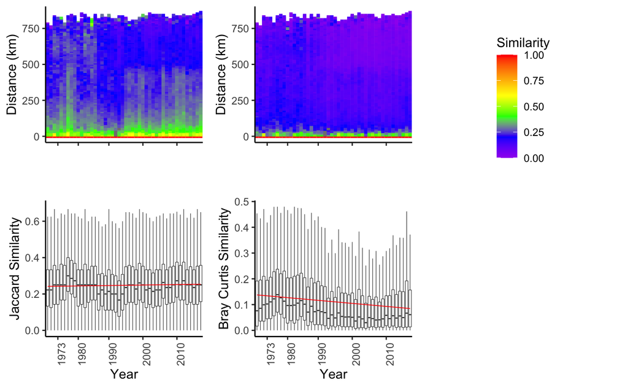

```r
ggsave(shelf_merge, path = here::here("figures","shelf"), file = "shelf_heat_boxplot_merge.jpg", width = 8, height = 5, unit = "in")
ggsave(shelf_merge, path = here::here("figures","shelf"), file = "shelf_heat_boxplot_merge.eps", width = 8, height = 5, unit = "in")
```

###maybe i’ll do this later? maybe not At its heart, this graphic is just a ggplot() with a geom_raster() layer. The complication is, geom_raster() requires equally spaced points in both the x- and y-direction. The rest of this post is about how to make that happen.

Linear Interpolation

I interpolate in the distance direction first, because I think this is the better assumption: as you go down further away, a reasonable way to estimate the similarity at a distance which you did not measure is to draw a straight line between the similarity at the distance that you did measure. (Not great, but sure)

```r
estimate_jac_sim_by_year <- function(target_year, target_distance) {
  data_for_year <- shelf_distances_dissimilarities_allyears[year == target_year]

  # approx() is one way to do a linear interpolation
  approx(data_for_year$distance, data_for_year$jaccard_similarity, xout = target_distance)$y
}

estimate_jac_sim_by_year(1990, c(0,3000,300000))
```

Expand data inputs

```r
temp_interp_depth <- data.table(expand.grid(
  # the same years as shelf spring
  year = shelf_years,
  # ddistances can now be any value
  distance = seq(0, max(shelf_distances_dissimilarities_allyears$distance), by = 10))
)

temp_interp_depth[,jaccard_similarity_modeled := estimate_jac_sim_by_year(year,distance), year]
```

Visualize

```r
ggplot(temp_interp_depth,aes(year,distance, color = jaccard_similarity_modeled)) +
  geom_point() +
   scale_colour_gradient2(
    midpoint = 0.5,
    high = scales::muted("red"),
    low = scales::muted("blue")
  )
```

[output not shown]

```r
estimate_jac_sim_by_distance <- function(target_distance, target_year) {
  data_for_distance <- temp_interp_depth[distance == target_distance,]
    setkey(data_for_distance, year)
  approx(data_for_distance$year, data_for_distance$jaccard_similarity_modeled, xout = target_year)$y
}

estimate_jac_sim_by_distance(
  target_distance = 1000000,
  target_year = c(1990,1998,2000)
)
```

Expand year grid

```r
jac_sim_raster <- data.table(expand.grid(
  # dates can now be any value
  year = seq(min(shelf_years), max(shelf_years), by = 1),
  # depths must be the same as in temp_interp_depth
  distance = unique(temp_interp_depth$distance))
)

jac_sim_raster[,jaccard_similarity_modeled := estimate_jac_sim_by_distance(distance,year),by = distance]
```

```r
ggplot(jac_sim_raster, aes(year, distance, fill = jaccard_similarity_modeled)) +
  geom_raster() +
  scale_fill_gradientn(colors =
c("purple" ,"blue"  , "green" , "yellow" ,"orange", "red")
  ) +
  coord_cartesian(expand = FALSE)
```

[output not shown]